# Model Fitting Exercise – Mavoglurant

Author

Alexandra Tejada-Strop

```r
# Load required packages
library(tidyverse)
library(tidymodels)
library(here)
```

## Data preparation

```r
dat_raw <- read_csv(here::here("fitting-exercise", "data", "Mavoglurant_A2121_nmpk.csv"))

glimpse(dat_raw)
```

```
Rows: 2,678
Columns: 17
$ ID   <dbl> 793, 793, 793, 793, 793, 793, 793, 793, 793, 793, 793, 793, 793, …
$ CMT  <dbl> 1, 2, 2, 2, 2, 2, 2, 2, 2, 2, 2, 2, 2, 2, 2, 2, 1, 2, 2, 2, 2, 2,…
$ EVID <dbl> 1, 0, 0, 0, 0, 0, 0, 0, 0, 0, 0, 0, 0, 0, 0, 0, 1, 0, 0, 0, 0, 0,…
$ EVI2 <dbl> 1, 0, 0, 0, 0, 0, 0, 0, 0, 0, 0, 0, 0, 0, 0, 0, 1, 0, 0, 0, 0, 0,…
$ MDV  <dbl> 1, 0, 0, 0, 0, 0, 0, 0, 0, 0, 0, 0, 0, 0, 0, 0, 1, 0, 0, 0, 0, 0,…
$ DV   <dbl> 0.00, 491.00, 605.00, 556.00, 310.00, 237.00, 147.00, 101.00, 72.…
$ LNDV <dbl> 0.000, 6.196, 6.405, 6.321, 5.737, 5.468, 4.990, 4.615, 4.282, 3.…
$ AMT  <dbl> 25, 0, 0, 0, 0, 0, 0, 0, 0, 0, 0, 0, 0, 0, 0, 0, 25, 0, 0, 0, 0, …
$ TIME <dbl> 0.000, 0.200, 0.250, 0.367, 0.533, 0.700, 1.200, 2.200, 3.200, 4.…
$ DOSE <dbl> 25, 25, 25, 25, 25, 25, 25, 25, 25, 25, 25, 25, 25, 25, 25, 25, 2…
$ OCC  <dbl> 1, 1, 1, 1, 1, 1, 1, 1, 1, 1, 1, 1, 1, 1, 1, 1, 1, 1, 1, 1, 1, 1,…
$ RATE <dbl> 75, 0, 0, 0, 0, 0, 0, 0, 0, 0, 0, 0, 0, 0, 0, 0, 150, 0, 0, 0, 0,…
$ AGE  <dbl> 42, 42, 42, 42, 42, 42, 42, 42, 42, 42, 42, 42, 42, 42, 42, 42, 2…
$ SEX  <dbl> 1, 1, 1, 1, 1, 1, 1, 1, 1, 1, 1, 1, 1, 1, 1, 1, 1, 1, 1, 1, 1, 1,…
$ RACE <dbl> 2, 2, 2, 2, 2, 2, 2, 2, 2, 2, 2, 2, 2, 2, 2, 2, 2, 2, 2, 2, 2, 2,…
$ WT   <dbl> 94.3, 94.3, 94.3, 94.3, 94.3, 94.3, 94.3, 94.3, 94.3, 94.3, 94.3,…
$ HT   <dbl> 1.769997, 1.769997, 1.769997, 1.769997, 1.769997, 1.769997, 1.769…
```

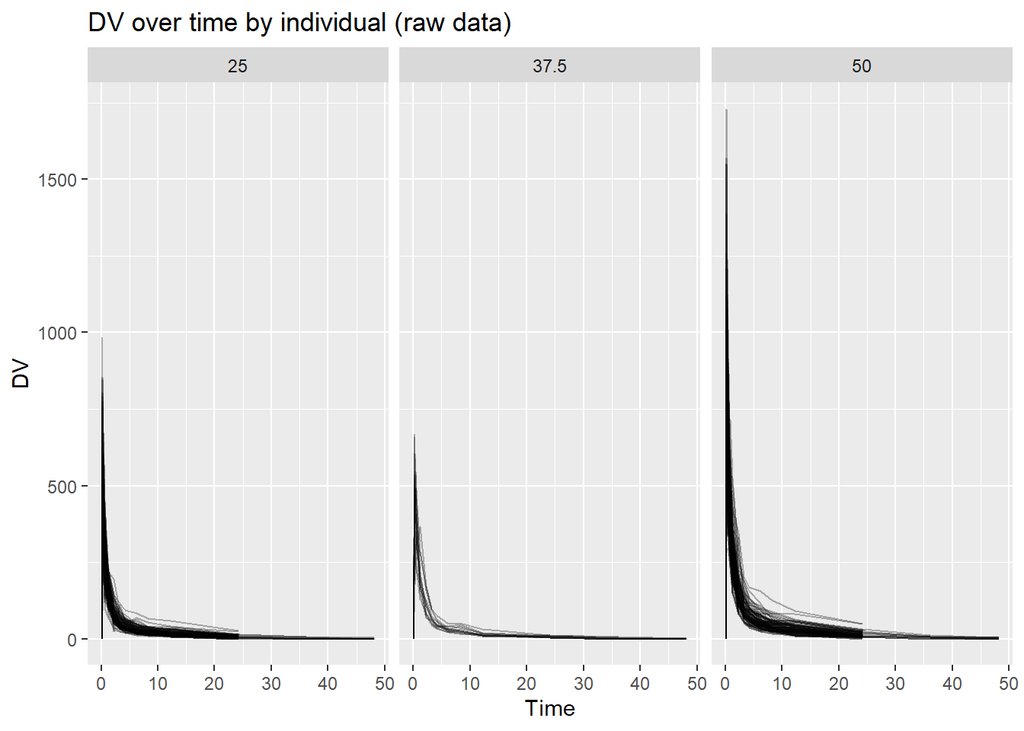

```r
# Plot DV over time for each person
dat_raw %>%
  ggplot(aes(x = TIME, y = DV, group = ID)) +
  geom_line(alpha = 0.3) +
  facet_wrap(~ DOSE) +
  labs(
    title = "DV over time by individual (raw data)",
    x = "Time",
    y = "DV"
  )
```

```r
# Keep only rows with OCC = 1
dat_occ1 <- dat_raw %>%
  filter(OCC == 1)

dat_occ1 %>% count(OCC)
```

```
# A tibble: 1 × 2
    OCC     n
  <dbl> <int>
1     1  1665
```

```r
# Create outcome Y by summing DV across post dose time points
y_df <- dat_occ1 %>%
  filter(TIME != 0) %>%
  group_by(ID) %>%
  summarise(Y = sum(DV, na.rm = TRUE), .groups = "drop")

dim(y_df)
```

```
[1] 120   2
```

```r
dose_df <- dat_occ1 %>%
  filter(TIME == 0)

dim(dose_df)
```

```
[1] 120  17
```

```r
dat_joined <- dose_df %>%
  left_join(y_df, by = "ID")

dim(dat_joined)
```

```
[1] 120  18
```

```r
glimpse(dat_joined)
```

```
Rows: 120
Columns: 18
$ ID   <dbl> 793, 794, 795, 796, 797, 798, 799, 800, 801, 802, 803, 804, 805, …
$ CMT  <dbl> 1, 1, 1, 1, 1, 1, 1, 1, 1, 1, 1, 1, 1, 1, 1, 1, 1, 1, 1, 1, 1, 1,…
$ EVID <dbl> 1, 1, 1, 1, 1, 1, 1, 1, 1, 1, 1, 1, 1, 1, 1, 1, 1, 1, 1, 1, 1, 1,…
$ EVI2 <dbl> 1, 1, 1, 1, 1, 1, 1, 1, 1, 1, 1, 1, 1, 1, 1, 1, 1, 1, 1, 1, 1, 1,…
$ MDV  <dbl> 1, 1, 1, 1, 1, 1, 1, 1, 1, 1, 1, 1, 1, 1, 1, 1, 1, 1, 1, 1, 1, 1,…
$ DV   <dbl> 0, 0, 0, 0, 0, 0, 0, 0, 0, 0, 0, 0, 0, 0, 0, 0, 0, 0, 0, 0, 0, 0,…
$ LNDV <dbl> 0, 0, 0, 0, 0, 0, 0, 0, 0, 0, 0, 0, 0, 0, 0, 0, 0, 0, 0, 0, 0, 0,…
$ AMT  <dbl> 25.0, 25.0, 25.0, 25.0, 25.0, 25.0, 25.0, 25.0, 25.0, 25.0, 25.0,…
$ TIME <dbl> 0, 0, 0, 0, 0, 0, 0, 0, 0, 0, 0, 0, 0, 0, 0, 0, 0, 0, 0, 0, 0, 0,…
$ DOSE <dbl> 25.0, 25.0, 25.0, 25.0, 25.0, 25.0, 25.0, 25.0, 25.0, 25.0, 25.0,…
$ OCC  <dbl> 1, 1, 1, 1, 1, 1, 1, 1, 1, 1, 1, 1, 1, 1, 1, 1, 1, 1, 1, 1, 1, 1,…
$ RATE <dbl> 75, 150, 150, 150, 150, 150, 150, 150, 150, 150, 150, 150, 225, 2…
$ AGE  <dbl> 42, 24, 31, 46, 41, 27, 23, 20, 23, 28, 46, 22, 43, 50, 19, 26, 3…
$ SEX  <dbl> 1, 1, 1, 2, 2, 1, 1, 1, 1, 1, 1, 1, 2, 2, 1, 1, 1, 1, 1, 1, 1, 1,…
$ RACE <dbl> 2, 2, 1, 1, 2, 2, 1, 88, 2, 1, 1, 1, 1, 1, 2, 2, 1, 1, 1, 1, 1, 1…
$ WT   <dbl> 94.3, 80.4, 71.8, 77.4, 64.3, 74.1, 87.9, 61.9, 65.3, 103.5, 83.0…
$ HT   <dbl> 1.769997, 1.759850, 1.809847, 1.649993, 1.560052, 1.829862, 1.850…
$ Y    <dbl> 2690.52, 2638.81, 2149.61, 1788.89, 3126.37, 2336.89, 3007.20, 27…
```

```r
# Keep only variables requested for this exercise
dat_clean <- dat_joined %>%
  transmute(
    Y = Y,
    DOSE = DOSE,
    AGE = AGE,
    SEX = factor(SEX),
    WT = WT,
    HT = HT
  )

dim(dat_clean)
```

```
[1] 120   6
```

```r
glimpse(dat_clean)
```

```
Rows: 120
Columns: 6
$ Y    <dbl> 2690.52, 2638.81, 2149.61, 1788.89, 3126.37, 2336.89, 3007.20, 27…
$ DOSE <dbl> 25.0, 25.0, 25.0, 25.0, 25.0, 25.0, 25.0, 25.0, 25.0, 25.0, 25.0,…
$ AGE  <dbl> 42, 24, 31, 46, 41, 27, 23, 20, 23, 28, 46, 22, 43, 50, 19, 26, 3…
$ SEX  <fct> 1, 1, 1, 2, 2, 1, 1, 1, 1, 1, 1, 1, 2, 2, 1, 1, 1, 1, 1, 1, 1, 1,…
$ WT   <dbl> 94.3, 80.4, 71.8, 77.4, 64.3, 74.1, 87.9, 61.9, 65.3, 103.5, 83.0…
$ HT   <dbl> 1.769997, 1.759850, 1.809847, 1.649993, 1.560052, 1.829862, 1.850…
```

```r
summary(dat_clean)
```

```
       Y               DOSE            AGE        SEX           WT
 Min.   : 826.4   Min.   :25.00   Min.   :18.00   1:104   Min.   : 56.60
 1st Qu.:1700.5   1st Qu.:25.00   1st Qu.:26.00   2: 16   1st Qu.: 73.17
 Median :2349.1   Median :37.50   Median :31.00           Median : 82.10
 Mean   :2445.4   Mean   :36.46   Mean   :33.00           Mean   : 82.55
 3rd Qu.:3050.2   3rd Qu.:50.00   3rd Qu.:40.25           3rd Qu.: 90.10
 Max.   :5606.6   Max.   :50.00   Max.   :50.00           Max.   :115.30
       HT
 Min.   :1.520
 1st Qu.:1.700
 Median :1.770
 Mean   :1.759
 3rd Qu.:1.813
 Max.   :1.930
```

# Exploratory data analysis

```r
dat_clean %>%
  summarise(
    n = n(),
    Y_mean = mean(Y, na.rm = TRUE),
    Y_sd = sd(Y, na.rm = TRUE),
    age_mean = mean(AGE, na.rm = TRUE),
    wt_mean = mean(WT, na.rm = TRUE),
    ht_mean = mean(HT, na.rm = TRUE)
  )
```

```
# A tibble: 1 × 6
      n Y_mean  Y_sd age_mean wt_mean ht_mean
  <int>  <dbl> <dbl>    <dbl>   <dbl>   <dbl>
1   120  2445.  962.       33    82.6    1.76
```

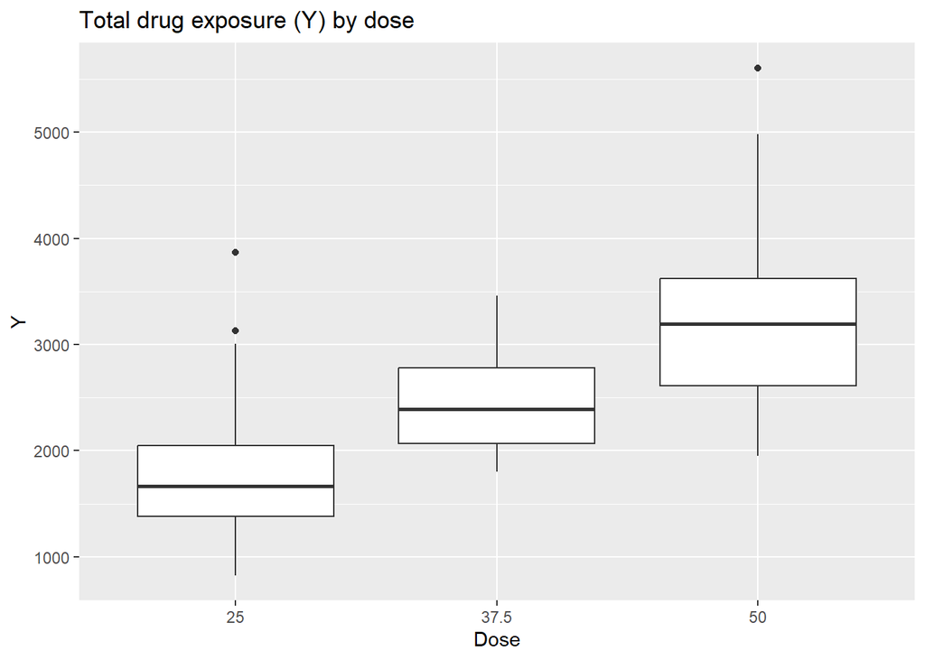

```r
dat_clean %>%
  ggplot(aes(x = factor(DOSE), y = Y)) +
  geom_boxplot() +
  labs(
    title = "Total drug exposure (Y) by dose",
    x = "Dose",
    y = "Y"
  )
```

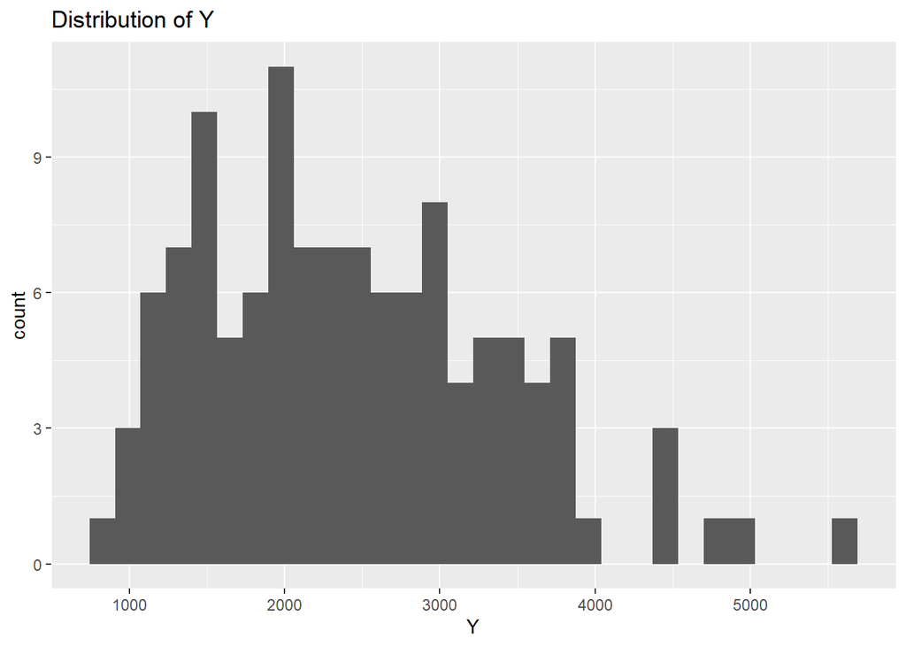

```r
dat_clean %>%
  ggplot(aes(Y)) +
  geom_histogram(bins = 30) +
  labs(title = "Distribution of Y")
```

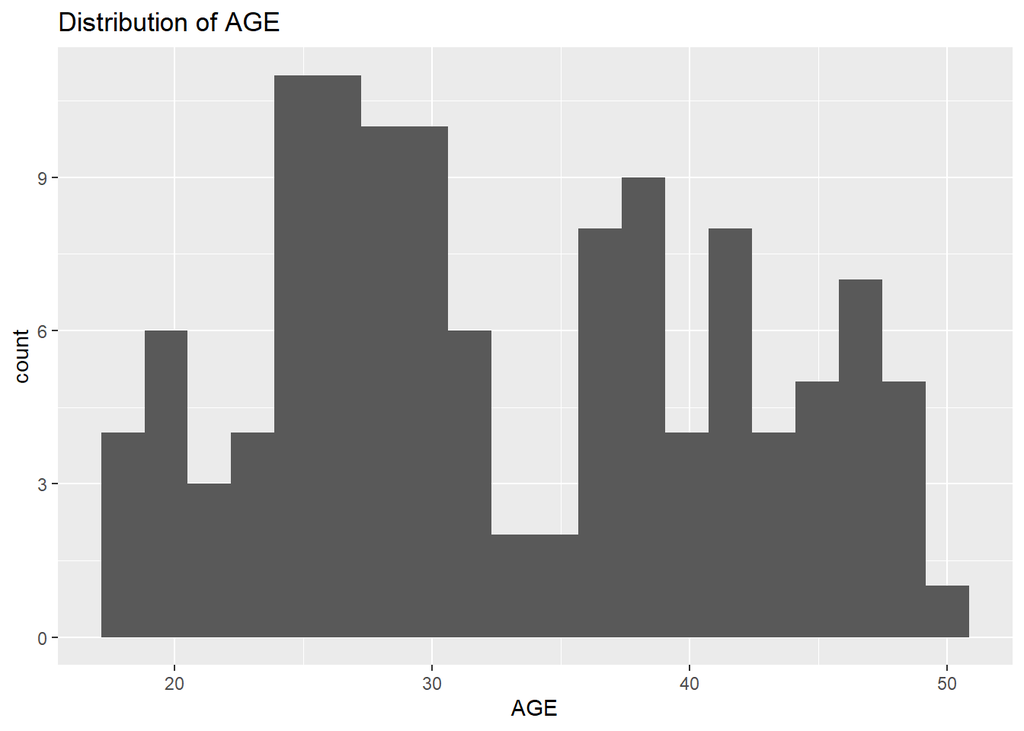

```r
dat_clean %>%
  ggplot(aes(AGE)) +
  geom_histogram(bins = 20) +
  labs(title = "Distribution of AGE")
```

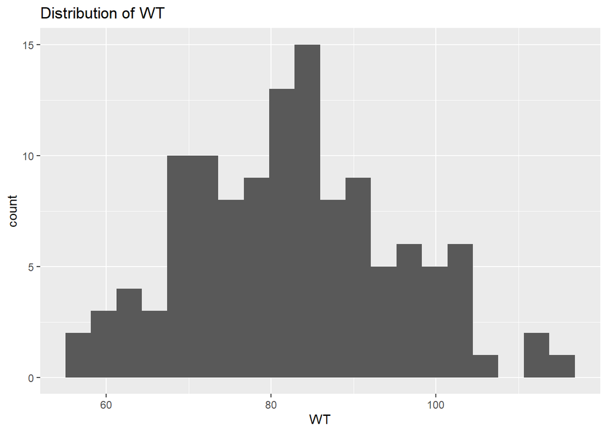

```r
dat_clean %>%
  ggplot(aes(WT)) +
  geom_histogram(bins = 20) +
  labs(title = "Distribution of WT")
```

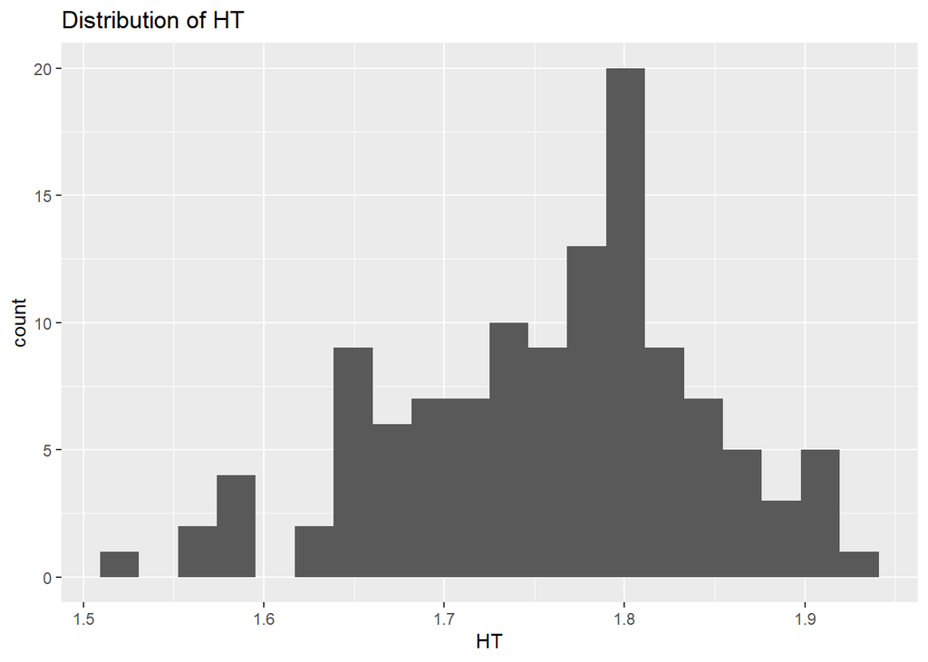

```r
dat_clean %>%
  ggplot(aes(HT)) +
  geom_histogram(bins = 20) +
  labs(title = "Distribution of HT")
```

# Model fitting and training RMSE

```r
# Set seed for reproducibility
rngseed <- 1234

set.seed(rngseed)
split_obj <- initial_split(dat_clean, prop = 0.75)

train_df <- training(split_obj)
test_df  <- testing(split_obj)

dim(train_df)
```

```
[1] 90  6
```

```r
dim(test_df)
```

```
[1] 30  6
```

```r
# Define and fit linear models
lm_spec <- linear_reg() %>%
  set_engine("lm")

# Model 1: DOSE only
lm_dose_fit <- lm_spec %>%
  fit(Y ~ DOSE, data = train_df)

# Model 2: all predictors
lm_all_fit <- lm_spec %>%
  fit(Y ~ DOSE + AGE + SEX + WT + HT, data = train_df)

# Training set predictions
lm_dose_preds_train <- predict(lm_dose_fit, new_data = train_df) %>%
  bind_cols(train_df %>% select(Y))

lm_all_preds_train <- predict(lm_all_fit, new_data = train_df) %>%
  bind_cols(train_df %>% select(Y))

# RMSE on training data
rmse_dose <- rmse(lm_dose_preds_train, truth = Y, estimate = .pred)
rmse_all  <- rmse(lm_all_preds_train, truth = Y, estimate = .pred)

# Null model
mean_y <- mean(train_df$Y)

null_preds <- train_df %>%
  mutate(.pred = mean_y)

rmse_null <- rmse(null_preds, truth = Y, estimate = .pred)

rmse_null
```

```
# A tibble: 1 × 3
  .metric .estimator .estimate
  <chr>   <chr>          <dbl>
1 rmse    standard        948.
```

```r
rmse_dose
```

```
# A tibble: 1 × 3
  .metric .estimator .estimate
  <chr>   <chr>          <dbl>
1 rmse    standard        703.
```

```r
rmse_all
```

```
# A tibble: 1 × 3
  .metric .estimator .estimate
  <chr>   <chr>          <dbl>
1 rmse    standard        627.
```

```r
rmse_compare_train <- bind_rows(
  rmse_null %>% mutate(model = "Null model"),
  rmse_dose %>% mutate(model = "Model 1: DOSE only"),
  rmse_all %>% mutate(model = "Model 2: All predictors")
) %>%
  select(model, .estimate)

rmse_compare_train
```

```
# A tibble: 3 × 2
  model                   .estimate
  <chr>                       <dbl>
1 Null model                   948.
2 Model 1: DOSE only           703.
3 Model 2: All predictors      627.
```

The training RMSE results show that the null model performed the worst. The model using dose only improved prediction compared to the null model. The full model with all predictors had the lowest RMSE, which means it performed the best on the training data.

# Cross validation

```r
set.seed(rngseed)
folds <- vfold_cv(train_df, v = 10)

wf_dose <- workflow() %>%
  add_model(lm_spec) %>%
  add_formula(Y ~ DOSE)

wf_all <- workflow() %>%
  add_model(lm_spec) %>%
  add_formula(Y ~ DOSE + AGE + SEX + WT + HT)

cv_dose <- fit_resamples(
  wf_dose,
  resamples = folds,
  metrics = metric_set(rmse)
)

cv_all <- fit_resamples(
  wf_all,
  resamples = folds,
  metrics = metric_set(rmse)
)

cv_dose_metrics <- collect_metrics(cv_dose)
cv_all_metrics  <- collect_metrics(cv_all)

cv_dose_metrics
```

```
# A tibble: 1 × 6
  .metric .estimator  mean     n std_err .config
  <chr>   <chr>      <dbl> <int>   <dbl> <chr>
1 rmse    standard    691.    10    67.5 pre0_mod0_post0
```

```r
cv_all_metrics
```

```
# A tibble: 1 × 6
  .metric .estimator  mean     n std_err .config
  <chr>   <chr>      <dbl> <int>   <dbl> <chr>
1 rmse    standard    646.    10    64.8 pre0_mod0_post0
```

```r
cv_compare <- bind_rows(
  cv_dose_metrics %>% mutate(model = "Model 1: DOSE only"),
  cv_all_metrics %>% mutate(model = "Model 2: All predictors")
) %>%
  select(model, .metric, mean, n, std_err)

cv_compare
```

```
# A tibble: 2 × 5
  model                   .metric  mean     n std_err
  <chr>                   <chr>   <dbl> <int>   <dbl>
1 Model 1: DOSE only      rmse     691.    10    67.5
2 Model 2: All predictors rmse     646.    10    64.8
```

The cross validation results showed the same overall pattern as the training RMSE results. Model 2 still performed better than Model 1, which suggests that adding AGE, SEX, WT, and HT improves prediction beyond dose alone. The standard errors were moderate, suggesting that model performance was reasonably stable across folds.

# Compare training RMSE to cross validation RMSE

```r
train_summary <- rmse_compare_train %>%
  rename(value = .estimate) %>%
  mutate(type = "Training RMSE")

cv_summary <- bind_rows(
  cv_dose_metrics %>%
    transmute(model = "Model 1: DOSE only", value = mean, type = "CV RMSE"),
  cv_all_metrics %>%
    transmute(model = "Model 2: All predictors", value = mean, type = "CV RMSE")
)

bind_rows(train_summary, cv_summary)
```

```
# A tibble: 5 × 3
  model                   value type
  <chr>                   <dbl> <chr>
1 Null model               948. Training RMSE
2 Model 1: DOSE only       703. Training RMSE
3 Model 2: All predictors  627. Training RMSE
4 Model 1: DOSE only       691. CV RMSE
5 Model 2: All predictors  646. CV RMSE
```

In general, the cross validation RMSE values are a little different from the training RMSE values because cross validation evaluates performance on data not used for fitting in each fold. Even so, the overall ranking of the models stayed the same.

```r
set.seed(999)
folds_seed2 <- vfold_cv(train_df, v = 10)

cv_dose_seed2 <- fit_resamples(
  wf_dose,
  resamples = folds_seed2,
  metrics = metric_set(rmse)
)

cv_all_seed2 <- fit_resamples(
  wf_all,
  resamples = folds_seed2,
  metrics = metric_set(rmse)
)

collect_metrics(cv_dose_seed2)
```

```
# A tibble: 1 × 6
  .metric .estimator  mean     n std_err .config
  <chr>   <chr>      <dbl> <int>   <dbl> <chr>
1 rmse    standard    705.    10    45.7 pre0_mod0_post0
```

```r
collect_metrics(cv_all_seed2)
```

```
# A tibble: 1 × 6
  .metric .estimator  mean     n std_err .config
  <chr>   <chr>      <dbl> <int>   <dbl> <chr>
1 rmse    standard    648.    10    52.7 pre0_mod0_post0
```

# Prediction plots

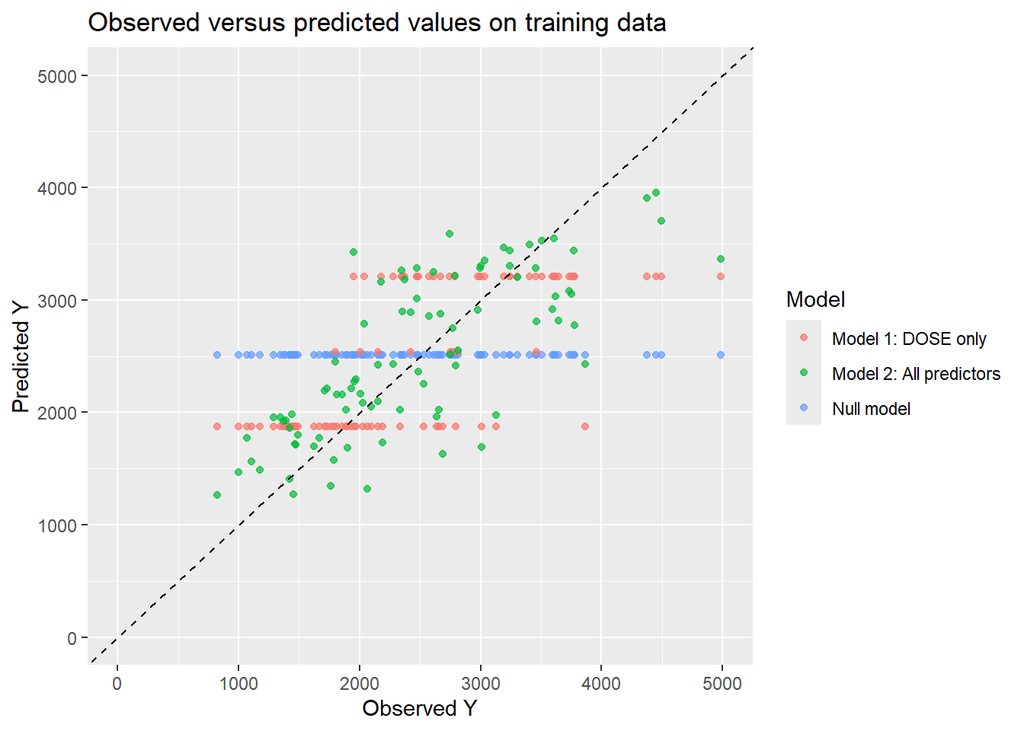

```r
# Predictions from all three models on the training data
null_preds_plot <- train_df %>%
  transmute(
    Y,
    .pred = mean_y,
    model = "Null model"
  )

dose_preds_plot <- lm_dose_preds_train %>%
  mutate(model = "Model 1: DOSE only") %>%
  select(Y, .pred, model)

all_preds_plot <- lm_all_preds_train %>%
  mutate(model = "Model 2: All predictors") %>%
  select(Y, .pred, model)

pred_plot_df <- bind_rows(
  null_preds_plot,
  dose_preds_plot,
  all_preds_plot
)

ggplot(pred_plot_df, aes(x = Y, y = .pred, color = model)) +
  geom_point(alpha = 0.7) +
  geom_abline(slope = 1, intercept = 0, linetype = "dashed") +
  coord_cartesian(xlim = c(0, 5000), ylim = c(0, 5000)) +
  labs(
    title = "Observed versus predicted values on training data",
    x = "Observed Y",
    y = "Predicted Y",
    color = "Model"
  )
```

The null model appears as a horizontal line because it predicts the same mean value for every observation. The dose only model falls along a few horizontal lines because dose only takes a small number of values, so the model gives only a few fitted values. The full model looks better overall, but there is still noticeable scatter around the diagonal line.

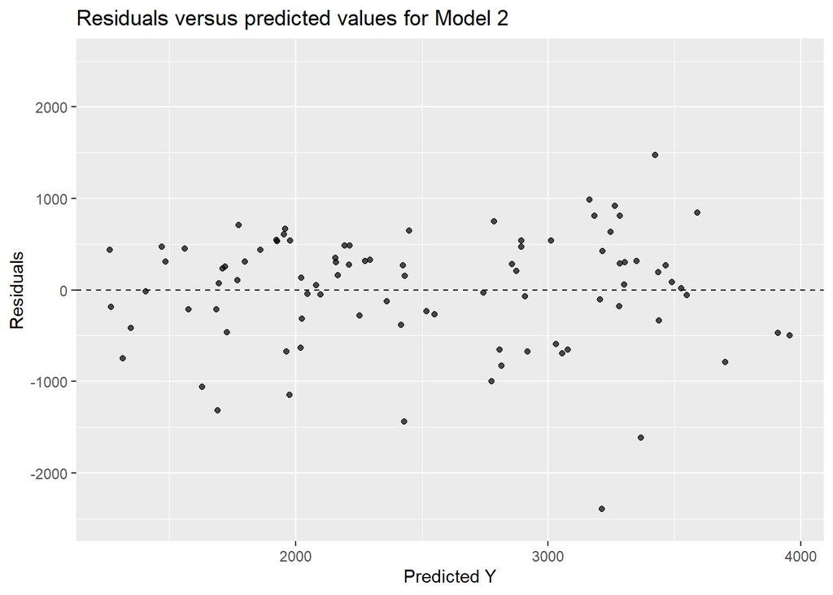

```r
resid_plot_df <- lm_all_preds_train %>%
  mutate(residual = .pred - Y)

ggplot(resid_plot_df, aes(x = .pred, y = residual)) +
  geom_point(alpha = 0.7) +
  geom_hline(yintercept = 0, linetype = "dashed") +
  coord_cartesian(ylim = c(-2500, 2500)) +
  labs(
    title = "Residuals versus predicted values for Model 2",
    x = "Predicted Y",
    y = "Residuals"
  )
```

For a good model, the residuals should look like a random cloud around zero. Here, there still seems to be some pattern, which suggests the model may still be missing some information or that the relationship may not be fully captured by a simple linear model.

# Bootstrap uncertainty

To quantify uncertainty around predictions from Model 2, I used bootstrap resampling on the training data and generated prediction intervals based on 100 bootstrap samples.

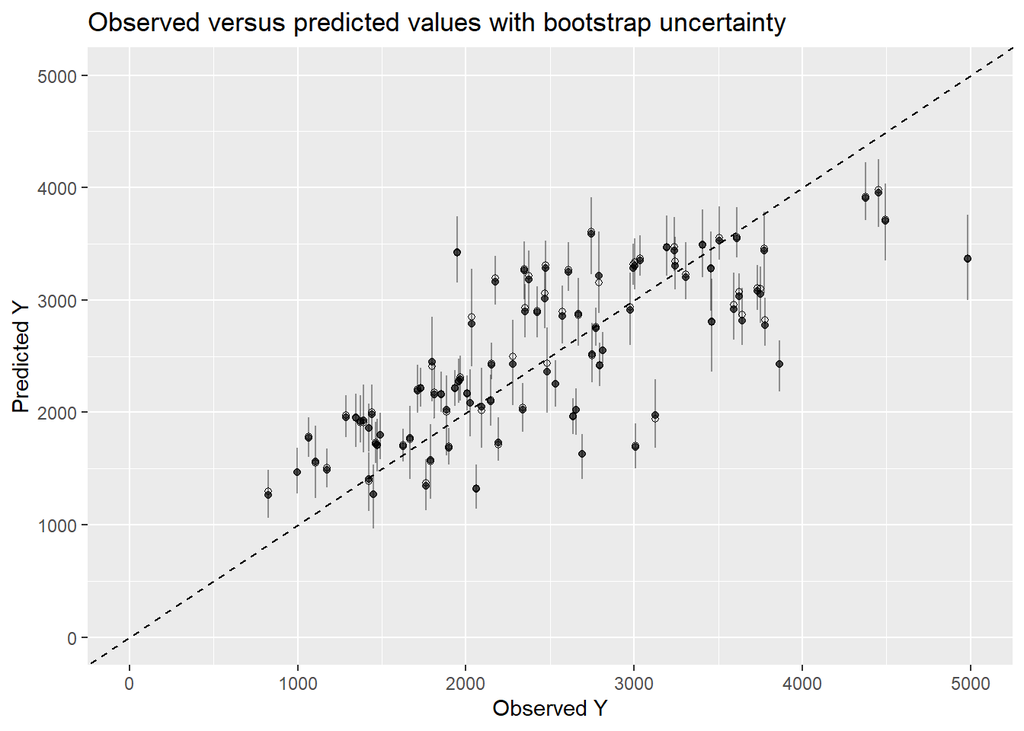

```r
set.seed(rngseed)
dat_bs <- bootstraps(train_df, times = 100)

pred_bs <- matrix(NA, nrow = 100, ncol = nrow(train_df))

for (i in 1:100) {
  dat_sample <- analysis(dat_bs$splits[[i]])

  bs_fit <- lm_spec %>%
    fit(Y ~ DOSE + AGE + SEX + WT + HT, data = dat_sample)

  pred_bs[i, ] <- predict(bs_fit, new_data = train_df)$.pred
}

preds <- apply(pred_bs, 2, quantile, c(0.055, 0.5, 0.945)) %>%
  t() %>%
  as.data.frame()

colnames(preds) <- c("lower", "median", "upper")

boot_plot_df <- train_df %>%
  select(Y) %>%
  bind_cols(
    lm_all_preds_train %>% select(.pred),
    preds
  )

ggplot(boot_plot_df, aes(x = Y)) +
  geom_point(aes(y = .pred), alpha = 0.7) +
  geom_point(aes(y = median), shape = 1) +
  geom_errorbar(aes(ymin = lower, ymax = upper), alpha = 0.4) +
  geom_abline(slope = 1, intercept = 0, linetype = "dashed") +
  coord_cartesian(xlim = c(0, 5000), ylim = c(0, 5000)) +
  labs(
    title = "Observed versus predicted values with bootstrap uncertainty",
    x = "Observed Y",
    y = "Predicted Y"
  )
```

The bootstrap plot adds uncertainty around the predictions from Model 2. Some observations have wider intervals than others, which suggests more uncertainty in those predictions. The model captures part of the overall pattern, but the spread around the diagonal line shows that prediction error still remains.

# Final test set evaluation

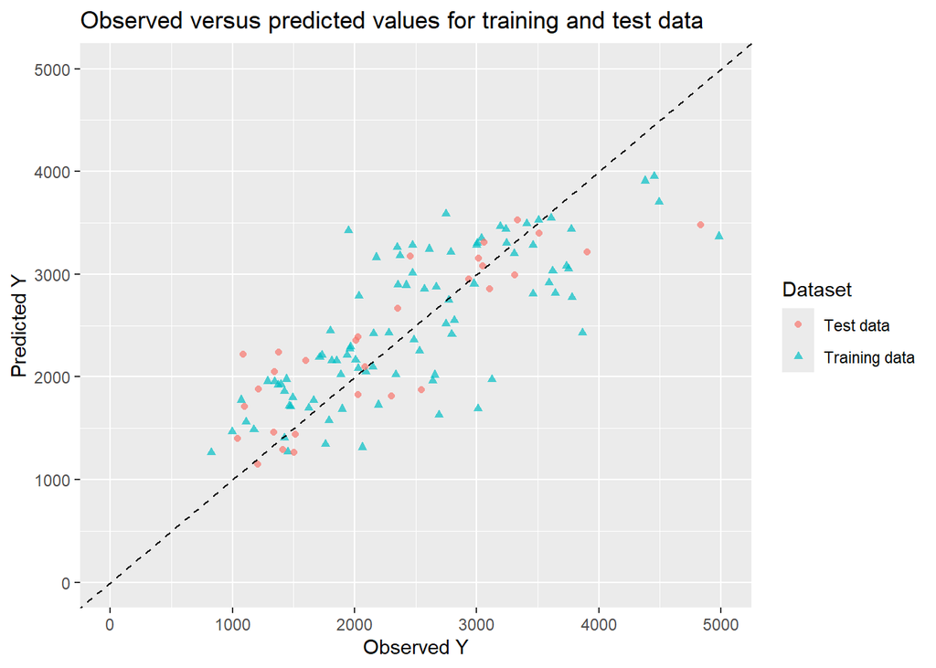

```r
# Predict on the test data using Model 2 fit on training data
lm_all_preds_test <- predict(lm_all_fit, new_data = test_df) %>%
  bind_cols(test_df %>% select(Y))

train_plot_df <- lm_all_preds_train %>%
  mutate(dataset = "Training data") %>%
  select(Y, .pred, dataset)

test_plot_df <- lm_all_preds_test %>%
  mutate(dataset = "Test data") %>%
  select(Y, .pred, dataset)

final_plot_df <- bind_rows(train_plot_df, test_plot_df)

ggplot(final_plot_df, aes(x = Y, y = .pred, color = dataset, shape = dataset)) +
  geom_point(alpha = 0.7) +
  geom_abline(slope = 1, intercept = 0, linetype = "dashed") +
  coord_cartesian(xlim = c(0, 5000), ylim = c(0, 5000)) +
  labs(
    title = "Observed versus predicted values for training and test data",
    x = "Observed Y",
    y = "Predicted Y",
    color = "Dataset",
    shape = "Dataset"
  )
```

The predicted versus observed plot for the test data shows that the test observations are generally mixed in with the training observations rather than being clearly separated. That is a good sign because it suggests the model is not obviously overfit to the training data.

```r
rmse_test_all <- rmse(lm_all_preds_test, truth = Y, estimate = .pred)

rmse_test_all
```

```
# A tibble: 1 × 3
  .metric .estimator .estimate
  <chr>   <chr>          <dbl>
1 rmse    standard        520.
```

```r
overall_summary <- tibble(
  model = c(
    "Null model",
    "Model 1: DOSE only",
    "Model 2: All predictors",
    "Model 2: Test data"
  ),
  rmse = c(
    rmse_null$.estimate,
    rmse_dose$.estimate,
    rmse_all$.estimate,
    rmse_test_all$.estimate
  )
)

overall_summary
```

```
# A tibble: 4 × 2
  model                    rmse
  <chr>                   <dbl>
1 Null model               948.
2 Model 1: DOSE only       703.
3 Model 2: All predictors  627.
4 Model 2: Test data       520.
```

# Model assessment

The null model performed the worst, which shows that using predictors improves performance over simply predicting the average outcome for everyone. Model 1, which used only dose, improved on the null model, but its predictions were still fairly limited because dose only takes a few values. Model 2 performed best overall, both in the training set and in cross validation, which suggests that including AGE, SEX, WT, and HT improves prediction.

Even so, Model 2 is still not perfect. The predicted versus observed and residual plots showed noticeable scatter, and the bootstrap plot showed uncertainty around many predictions. That means the model captures some important structure in the data, but there is still unexplained variation. For a real scientific application, I would consider Model 2 better than the other models here, but I would still be cautious about calling it fully adequate without exploring more flexible model forms or additional predictors.

# Use of AI tools

AI tools were used to assist with debugging, clarifying error messages, and reviewing tidymodels syntax.

# This section added by MARCO REINA

```r
#Alex have completed part 2 by herself already but there was some room for improvement, here is some of the details I noticed it that could be improved
#Code originally written by MR, and improved with Qween

#dataset containing race (original)

dat_clean0 <- dat_joined %>%
  transmute(
    Y = Y,
    DOSE = DOSE,
    AGE = AGE,
    SEX = factor(SEX),
    RACE = factor(RACE),
    WT = WT,
    HT = HT
  )

#Original models re made
lm_null_model0 <- lm_spec %>%
  fit(Y ~ 1, data = dat_clean0) #using dat_clean0

lm_first_model0 <- lm_spec %>%
  fit(Y ~ DOSE, data = dat_clean0)

lm_second_model0 <- lm_spec %>%
  fit(Y ~ DOSE + AGE + SEX + RACE + WT + HT, data = dat_clean0)

#PART 2
#predicted values
dat_clean0 <- dat_clean0 %>%
  mutate(
    pred_null = predict(lm_null_model0, new_data = dat_clean0, type = "numeric")$.pred,
    pred_mod1 = predict(lm_first_model0, new_data = dat_clean0, type = "numeric")$.pred,
    pred_mod2 = predict(lm_second_model0, new_data = dat_clean0, type = "numeric")$.pred
  )
```

```r
# Create a long-format data frame for plotting
pred_long_format <- dat_clean0 %>%
  select(Y, pred_null, pred_mod1, pred_mod2) %>%
  pivot_longer(
    cols = starts_with("pred_"),
    names_to = "model",
    values_to = "prediction"
  ) %>%
  # Clean up model labels for nicer legend
  mutate(
    model = case_when(
      model == "pred_null" ~ "Null Model",
      model == "pred_mod1" ~ "Model 1 (DOSE)",
      model == "pred_mod2" ~ "Model 2 (Full)",
      TRUE ~ model
    )
  )
```

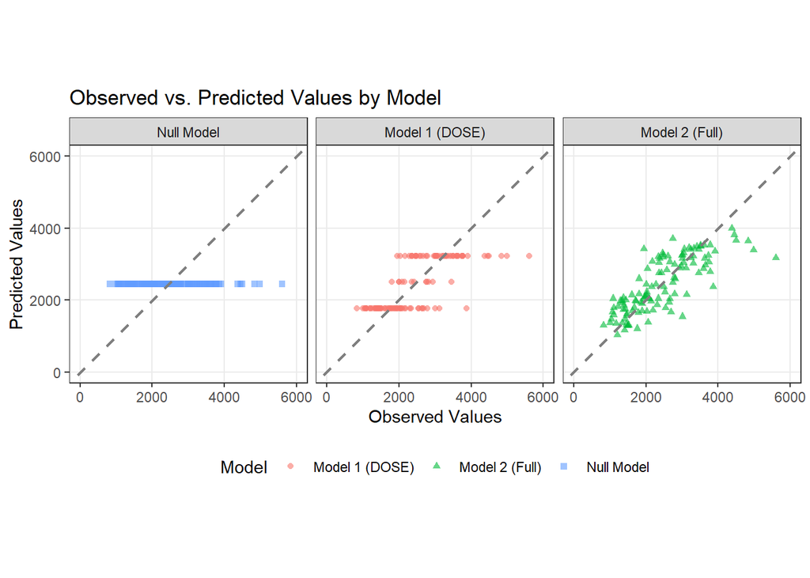

```r
# Plotting observed vs predicted
ggplot(pred_long_format, aes(x = Y, y = prediction, color = model, shape = model)) +
  geom_point(alpha = 0.6, size = 1.5) +
  geom_abline(slope = 1, intercept = 0, color = "gray50", linewidth = 0.8, linetype = "dashed") +
  scale_x_continuous(limits = c(0, 6000)) + # englarged to 6000 because there were values outside the plot
  scale_y_continuous(limits = c(0, 6000)) + # englarged to 6000 because there were values outside the plot
  coord_fixed(ratio = 1) +  # Ensures 45° line appears at true 45°
  labs(
    title = "Observed vs. Predicted Values by Model",
    x = "Observed Values",
    y = "Predicted Values",
    color = "Model",
    shape = "Model"
  ) +
  theme_bw() +
  theme(
    panel.grid.minor = element_blank(),
    legend.position = "bottom"
  ) +
  facet_wrap(~ factor(model,
  levels = c("Null Model", "Model 1 (DOSE)", "Model 2 (Full)")))
```

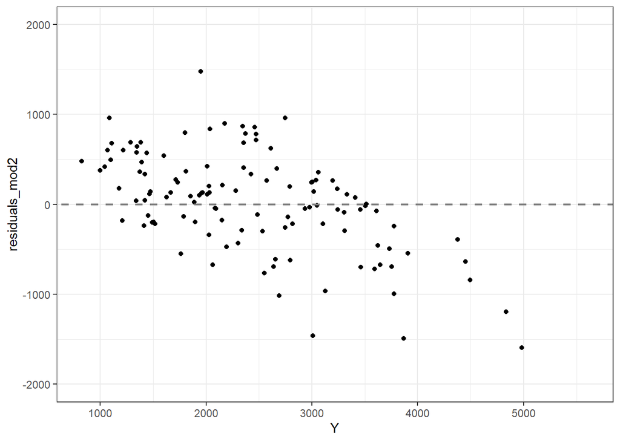

```r
#Plotting residuals
dat_clean0$residuals_mod2 <- dat_clean0$pred_mod2 - dat_clean0$Y

ggplot(dat_clean0, aes(x = Y, y = residuals_mod2)) +
  geom_point() +
  geom_abline(slope = 0, intercept = 0, color = "gray50", linewidth = 0.8, linetype = "dashed") +
  ylim(-2000, 2000) + #only 1 value left out to make it more visible
  theme_bw()
```

```r
set.seed(rngseed) #seed set as rngseed

# Create 100 bootstrap samples from training data
dat_bs <- bootstraps(train_df, times = 100)

num_obs <- nrow(train_df)
pred_bs <- matrix(NA, nrow = 100, ncol = num_obs)

for (i in 1:100) {
  # Get the i-th bootstrap sample
  dat_sample <- rsample::analysis(dat_bs$splits[[i]])

  # Fit the model (Model 2: all predictors) to this sample
  bs_fit <- linear_reg() |>
    set_engine("lm") |>
    fit(Y ~ DOSE + AGE + SEX + WT + HT, data = dat_sample)

  # Predict for the ORIGINAL training data
  # Use pull(.pred) to get a numeric vector instead of a dataframe
  pred_bs[i, ] <- predict(bs_fit, new_data = dat_sample) |> pull(.pred)
}

preds <- pred_bs |> apply(2, quantile, c(0.055, 0.5, 0.945)) |> t()
```

```r
# Get the original predictions from the Model 2 fit on training data

aug_train <- augment(lm_all_fit, new_data = train_df)

# Combine with the bootstrap results (the 'preds' matrix from the previous step)
# This assumes 'preds' has columns for 5.5%, 50%, and 94.5% quantiles
plot_data <- aug_train |>
  mutate(
    bs_low = preds[, 1],
    bs_med = preds[, 2],
    bs_high = preds[, 3]
  )
```

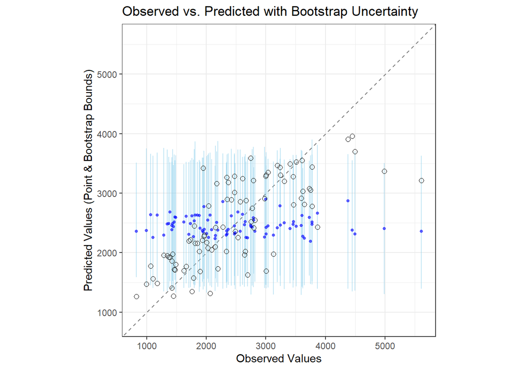

```r
#Plotting the bootstrap results

ggplot(plot_data, aes(x = Y)) +
  # 45-degree reference line (Ideal model)
  geom_abline(intercept = 0, slope = 1, linetype = "dashed", color = "grey50") +
  # Bootstrap intervals (Upper and Lower bounds)
  geom_errorbar(aes(ymin = bs_low, ymax = bs_high), color = "skyblue", alpha = 0.5) +
  # Bootstrap median
  geom_point(aes(y = bs_med), color = "blue", size = 1, alpha = 0.6) +
  # Original point estimate (Original predictions)
  geom_point(aes(y = .pred), color = "black", shape = 1, size = 2) +
  # Formatting
  labs(
    x = "Observed Values",
    y = "Predicted Values (Point & Bootstrap Bounds)",
    title = "Observed vs. Predicted with Bootstrap Uncertainty"
  ) +
  # Ensure x and y axes are on the same scale
  coord_obs_pred() +
  theme_bw()
```